# Processing the WiR data

Stuart Rosen & Sam Evans - to accompany Evans & Rosen (2021) JSLHR

09 September 2021

- SC = Cooper 2011 BSc Speech Sciences UCL
- RL = Lancaster 2009 IBSc UCL (containing earlier data from Emmbrook study)
- GY = control listeners from Guy’s study
- HR = Roe 2008 BSc Audiology UCL
- HW = Williams 2012 BSc Audiology UCL
- CR = Redey-Nagy 2009 PhD UCL: 19 children

### Numbers of listeners in each sub-study, and the total

```
## # A tibble: 6 x 2
##   study     n
## * <fct> <int>
## 1 CR       19
## 2 GY       17
## 3 HR       17
## 4 HW       18
## 5 RL       54
## 6 SC       30
```

```
##     n
## 1 155
```

### Here is the essential raw data before any data removals or adjustments

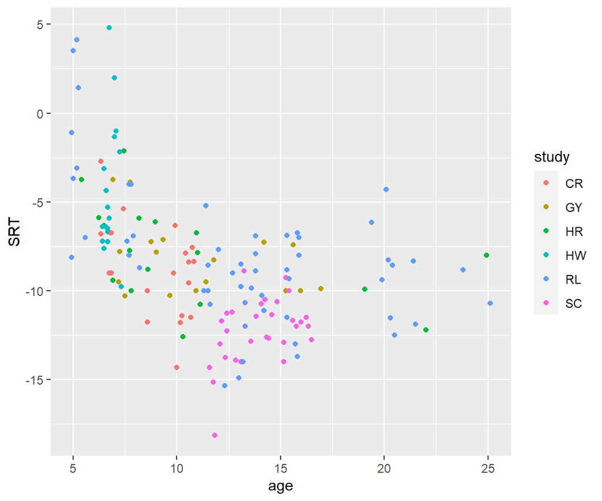

### Are the studies consistent in the SRTs for children aged 11 and up? (Figure 2 from the paper)

Given the evidence that SRTs do not appear to change after age 11, we compare SRTs across the 4 studies for those groups of older participants (number in each sub-study given below). Note that HW & CR have no older listeners.

```
## # A tibble: 4 x 2
##   study     n
## * <fct> <int>
## 1 GY        7
## 2 HR        5
## 3 RL       40
## 4 SC       30
```

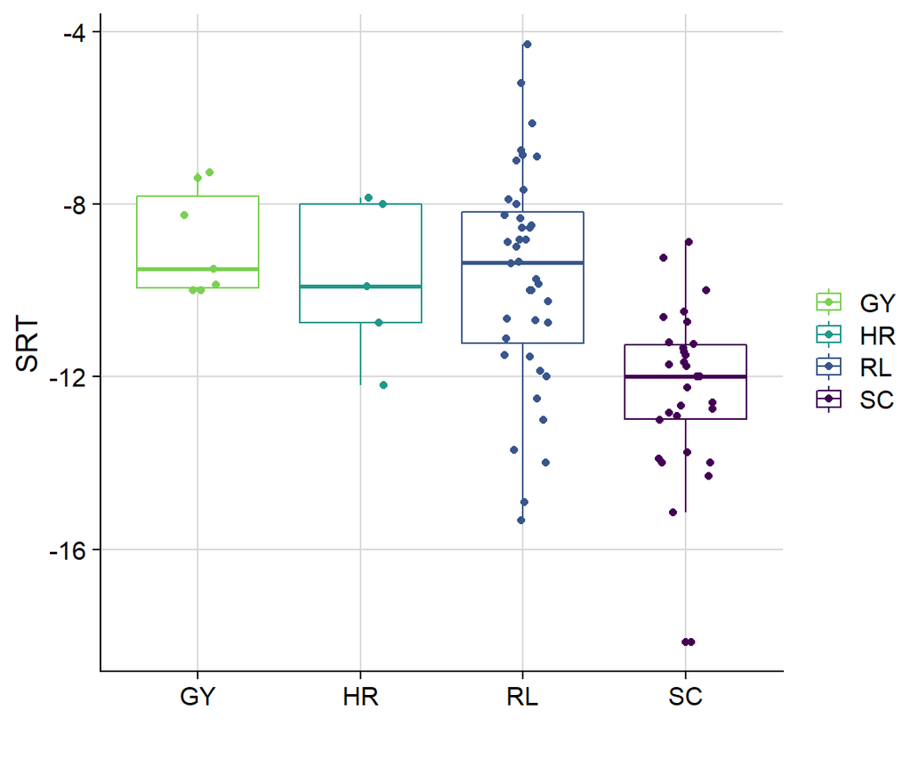

#### A one-way ANOVA with a follow-up Tukey post-hoc test shows that the mean SRTs are not the same in the 4 groups (f (3, 78) = 9.98, p = 1.22e-05). The SRTs for SC are significantly lower than from RL and GY (both ps < 0.003). SC and HR are not significantly different (p = 0.09) even though the absolute difference in means is very similar to the other two groups, presumably because there are only 5 listeners in the HR group.

```
##
## Call:
## lm(formula = SRT ~ study, data = dCmp)
##
## Residuals:
##     Min      1Q  Median      3Q     Max
## -5.8736 -1.0967  0.2693  1.3935  5.3644
##
## Coefficients:
##             Estimate Std. Error t value Pr(>|t|)
## (Intercept)  -8.8997     0.8243 -10.796  < 2e-16 ***
## studyHR      -0.8418     1.2770  -0.659 0.511739
## studyRL      -0.7647     0.8935  -0.856 0.394737
## studySC      -3.3696     0.9154  -3.681 0.000426 ***
## ---
## Signif. codes:  0 '***' 0.001 '**' 0.01 '*' 0.05 '.' 0.1 ' ' 1
##
## Residual standard error: 2.181 on 78 degrees of freedom
## Multiple R-squared:  0.2773, Adjusted R-squared:  0.2495
## F-statistic: 9.978 on 3 and 78 DF,  p-value: 1.218e-05
```

```
## Analysis of Variance Table
##
## Response: SRT
##           Df Sum Sq Mean Sq F value    Pr(>F)
## study      3 142.38  47.460   9.978 1.218e-05 ***
## Residuals 78 371.00   4.756
## ---
## Signif. codes:  0 '***' 0.001 '**' 0.01 '*' 0.05 '.' 0.1 ' ' 1
```

```
##             Df Sum Sq Mean Sq F value   Pr(>F)
## study        3  142.4   47.46   9.978 1.22e-05 ***
## Residuals   78  371.0    4.76
## ---
## Signif. codes:  0 '***' 0.001 '**' 0.01 '*' 0.05 '.' 0.1 ' ' 1
```

```
##   Tukey multiple comparisons of means
##     95% family-wise confidence level
##
## Fit: aov(formula = SRT ~ study, data = dCmp)
##
## $study
##              diff       lwr        upr     p adj
## HR-GY -0.84175325 -4.194313  2.5108062 0.9120102
## RL-GY -0.76467637 -3.110470  1.5811173 0.8274363
## SC-GY -3.36958319 -5.772900 -0.9662659 0.0023636
## RL-HR  0.07707688 -2.638807  2.7929605 0.9998503
## SC-HR -2.52782995 -5.293550  0.2378905 0.0855719
## SC-RL -2.60490683 -3.987767 -1.2220466 0.0000251
```

```
##         g2       mean       min    max  n
## 1 RL+GY+HR  -9.568826 -15.33333 -4.300 52
## 2       SC -12.269259 -18.14286 -8.875 30
```

```
## [1] Aggregating RL+GY+HR into one group shows a mean difference of 2.7 dB between this group of 3 and SC.
```

#### As SC only had participants aged 11.6-16.5 years (in secondary school), it seemed undesirable to leave the SRTs as is, because this overall effect on model fits would not be distributed across the age range, particularly for younger children where developmental changes are obvious. Therefore, SRTs for the SC study were all adjusted upwards by 2.7 dB, after which a one-way ANOVA confirmed no differences across the groups (f(3,78) = 0.256, p = 0.857).

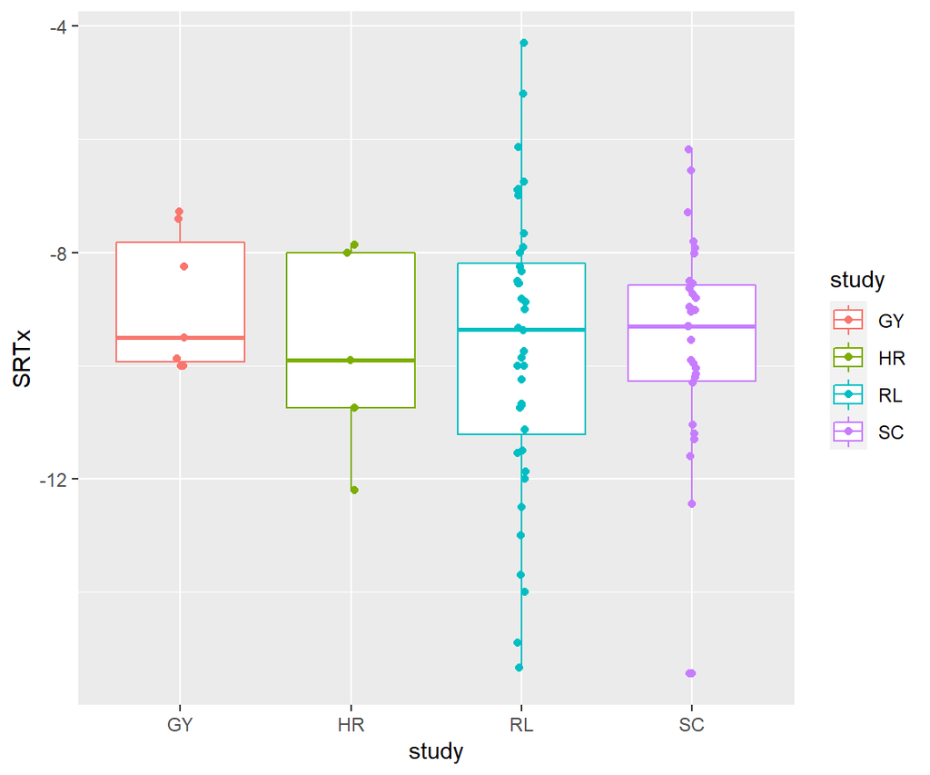

```
##             Df Sum Sq Mean Sq F value Pr(>F)
## study        3    3.6   1.216   0.256  0.857
## Residuals   78  371.0   4.756
```

### Data set after adjustments to SC

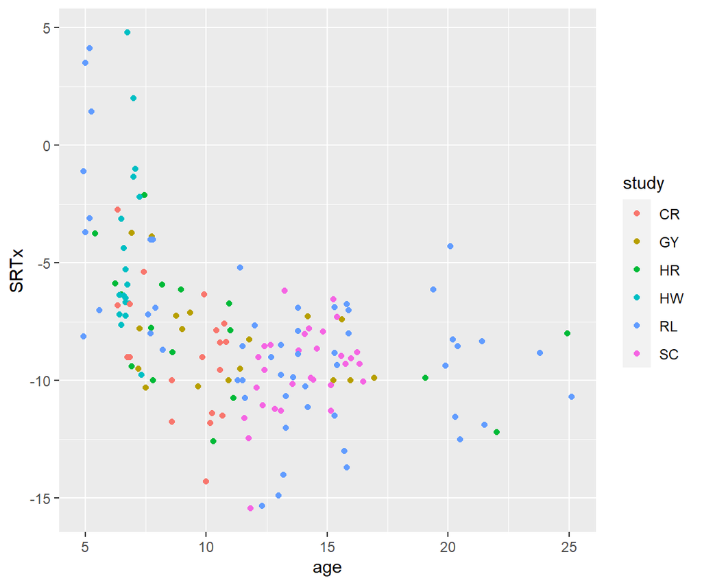

### Do an initial segmented regression to delete outlying points, first showing that there is no evidence for the upper segment to have a slope different from 0.

```
##
## Formula: SRTx ~ TwoLinesFCT(age, slope1, slope2, int1, brk)
##
## Parameters:
##        Estimate Std. Error t value Pr(>|t|)
## slope1 -1.59748    0.30404  -5.254 4.98e-07 ***
## slope2  0.05638    0.07734   0.729  0.46718
## int1    5.64881    2.16285   2.612  0.00992 **
## brk     9.70180    0.59971  16.178  < 2e-16 ***
## ---
## Signif. codes:  0 '***' 0.001 '**' 0.01 '*' 0.05 '.' 0.1 ' ' 1
##
## Residual standard error: 2.62 on 151 degrees of freedom
##
## Number of iterations to convergence: 3
## Achieved convergence tolerance: 6.532e-08
```

```
##
## Formula: SRTx ~ TwoLinesFCT(age, slope1, 0, int1, brk)
##
## Parameters:
##        Estimate Std. Error t value Pr(>|t|)
## slope1  -1.5785     0.3191  -4.947 1.98e-06 ***
## int1     5.5244     2.2533   2.452   0.0154 *
## brk      9.5755     0.5925  16.161  < 2e-16 ***
## ---
## Signif. codes:  0 '***' 0.001 '**' 0.01 '*' 0.05 '.' 0.1 ' ' 1
##
## Residual standard error: 2.616 on 152 degrees of freedom
##
## Number of iterations to convergence: 4
## Achieved convergence tolerance: 1.969e-09
```

```
## Analysis of Variance Table
##
## Model 1: SRTx ~ TwoLinesFCT(age, slope1, slope2, int1, brk)
## Model 2: SRTx ~ TwoLinesFCT(age, slope1, 0, int1, brk)
##   Res.Df Res.Sum Sq Df  Sum Sq F value Pr(>F)
## 1    151     1036.4
## 2    152     1040.2 -1 -3.8302   0.558 0.4562
```

### Now find points more than 3 standard deviations from the mean, and delete them. Only one point is identified, and after re-fitting, another. Then all remaining points have z-scores within +/- 3 dB

```
##
## Formula: SRTx ~ TwoLinesFCT(age, slope1, 0, int1, brk)
##
## Parameters:
##        Estimate Std. Error t value Pr(>|t|)
## slope1  -1.5785     0.3191  -4.947 1.98e-06 ***
## int1     5.5244     2.2533   2.452   0.0154 *
## brk      9.5755     0.5925  16.161  < 2e-16 ***
## ---
## Signif. codes:  0 '***' 0.001 '**' 0.01 '*' 0.05 '.' 0.1 ' ' 1
##
## Residual standard error: 2.616 on 152 degrees of freedom
##
## Number of iterations to convergence: 4
## Achieved convergence tolerance: 1.49e-08
##
## [1] Standard deviation of the residuals= 2.6
```

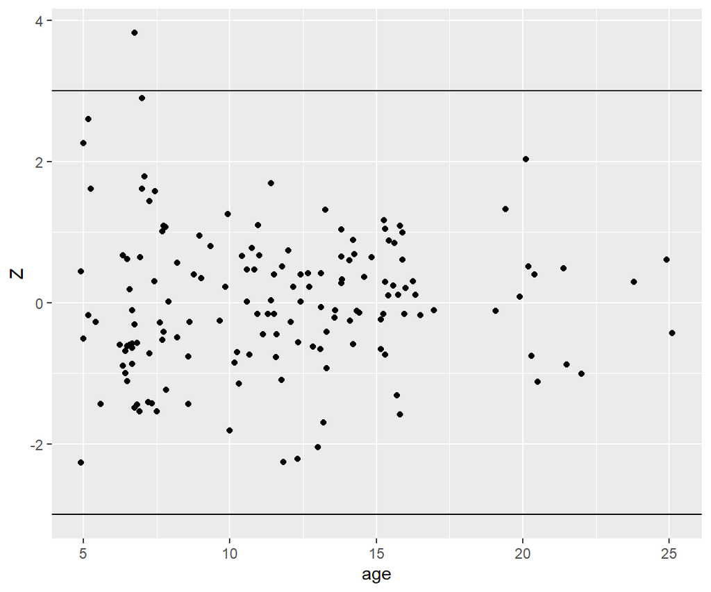

```
## [1] Maximum magnitude z score= 3.8208
```

```
## [1] Excluded listeners:
##   listener                         fileName  age study SRT  fitASYMP        Z
## 1      hq8 A_hq8a_pos_18-Jan-2012_09-28.csv 6.75    HW 4.8 -5.130332 3.820835
```

```
##
## Formula: SRTx ~ TwoLinesFCT(age, slope1, 0, int1, brk)
##
## Parameters:
##        Estimate Std. Error t value Pr(>|t|)
## slope1  -1.5440     0.3044  -5.072 1.14e-06 ***
## int1     5.1092     2.1513   2.375   0.0188 *
## brk      9.5206     0.5683  16.754  < 2e-16 ***
## ---
## Signif. codes:  0 '***' 0.001 '**' 0.01 '*' 0.05 '.' 0.1 ' ' 1
##
## Residual standard error: 2.495 on 151 degrees of freedom
##
## Number of iterations to convergence: 4
## Achieved convergence tolerance: 1.49e-08
##
## [1] Standard deviation of the residuals= 2.48
```

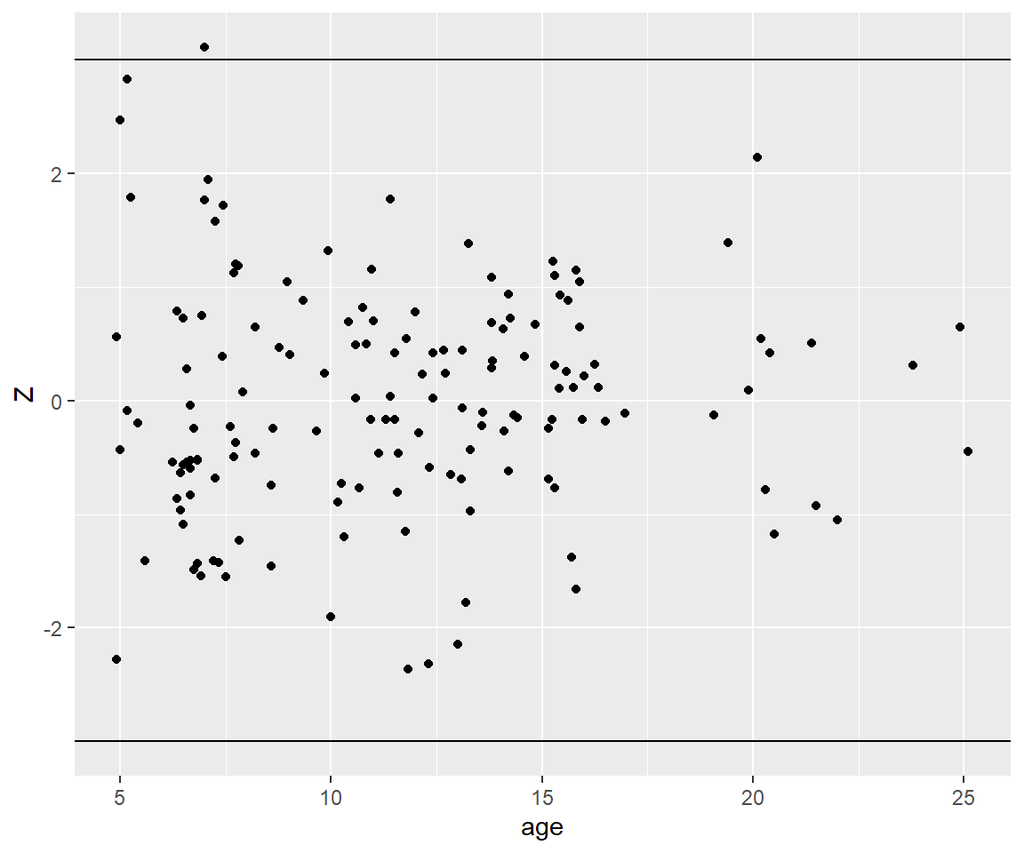

```
## [1] Maximum magnitude z score= 3.1063
```

```
## [1] Excluded listeners:
##   listener                          fileName age study SRT  fitASYMP       Z
## 1      hq7 A_hq7a_corr_17-Jan-2012_14-31.csv   7    HW   2 -5.698599 3.10625
```

```
##
## Formula: SRTx ~ TwoLinesFCT(age, slope1, 0, int1, brk)
##
## Parameters:
##        Estimate Std. Error t value Pr(>|t|)
## slope1  -1.6366     0.3087  -5.301 4.04e-07 ***
## int1     5.5723     2.1674   2.571   0.0111 *
## brk      9.2494     0.5019  18.430  < 2e-16 ***
## ---
## Signif. codes:  0 '***' 0.001 '**' 0.01 '*' 0.05 '.' 0.1 ' ' 1
##
## Residual standard error: 2.421 on 150 degrees of freedom
##
## Number of iterations to convergence: 6
## Achieved convergence tolerance: 1.49e-08
##
## [1] Standard deviation of the residuals= 2.41
```

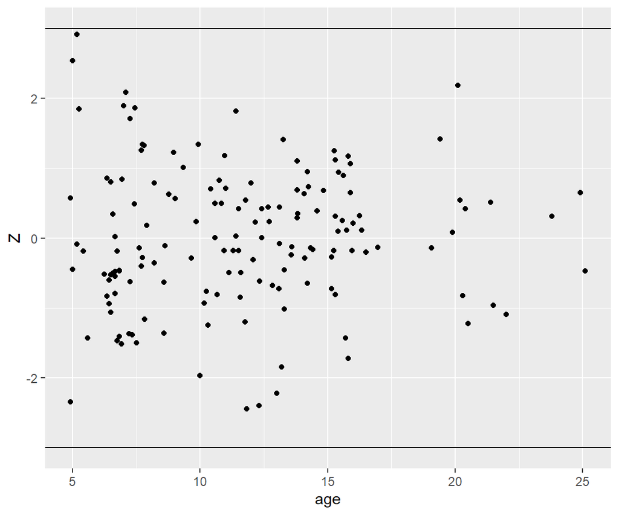

```
## [1] Maximum magnitude z score= 2.9158
```

### Check again, with the final data set that there is no evidence for the upper segment to have a slope different from 0, and also that the broken stick is better than a simple line.

```
##
## Formula: SRTx ~ TwoLinesFCT(age, slope1, slope2, int1, brk)
##
## Parameters:
##        Estimate Std. Error t value Pr(>|t|)
## slope1 -1.54590    0.29578  -5.227 5.74e-07 ***
## slope2  0.05798    0.07087   0.818   0.4146
## int1    4.98518    2.09072   2.384   0.0184 *
## brk     9.60731    0.58560  16.406  < 2e-16 ***
## ---
## Signif. codes:  0 '***' 0.001 '**' 0.01 '*' 0.05 '.' 0.1 ' ' 1
##
## Residual standard error: 2.424 on 149 degrees of freedom
##
## Number of iterations to convergence: 3
## Achieved convergence tolerance: 5.556e-08
```

```
##
## Formula: SRTx ~ TwoLinesFCT(age, slope1, 0, int1, brk)
##
## Parameters:
##        Estimate Std. Error t value Pr(>|t|)
## slope1  -1.6366     0.3087  -5.301 4.04e-07 ***
## int1     5.5723     2.1674   2.571   0.0111 *
## brk      9.2494     0.5019  18.430  < 2e-16 ***
## ---
## Signif. codes:  0 '***' 0.001 '**' 0.01 '*' 0.05 '.' 0.1 ' ' 1
##
## Residual standard error: 2.421 on 150 degrees of freedom
##
## Number of iterations to convergence: 3
## Achieved convergence tolerance: 2.184e-09
```

```
##
## Call:
## lm(formula = SRTx ~ age, data = d)
##
## Residuals:
##     Min      1Q  Median      3Q     Max
## -7.1839 -1.6904 -0.0779  1.4458 10.2284
##
## Coefficients:
##             Estimate Std. Error t value Pr(>|t|)
## (Intercept) -4.43048    0.63036  -7.028 6.72e-11 ***
## age         -0.32358    0.05032  -6.431 1.58e-09 ***
## ---
## Signif. codes:  0 '***' 0.001 '**' 0.01 '*' 0.05 '.' 0.1 ' ' 1
##
## Residual standard error: 2.836 on 151 degrees of freedom
## Multiple R-squared:  0.215,  Adjusted R-squared:  0.2098
## F-statistic: 41.36 on 1 and 151 DF,  p-value: 1.578e-09
```

```
## Analysis of Variance Table
##
## Model 1: SRTx ~ TwoLinesFCT(age, slope1, slope2, int1, brk)
## Model 2: SRTx ~ TwoLinesFCT(age, slope1, 0, int1, brk)
## Model 3: SRTx ~ age
##   Res.Df Res.Sum Sq Df  Sum Sq F value    Pr(>F)
## 1    149     875.55
## 2    150     879.49 -1   -3.93  0.6693    0.4146
## 3    151    1214.65 -1 -335.17 57.1639 3.705e-12 ***
## ---
## Signif. codes:  0 '***' 0.001 '**' 0.01 '*' 0.05 '.' 0.1 ' ' 1
```

### Now fit an asymptotic regression model

```
##
## Formula: SRTx ~ asympRegrFCT(age, b1, b2, b3)
##
## Parameters:
##    Estimate Std. Error t value Pr(>|t|)
## b1  -9.7046     0.3082 -31.488  < 2e-16 ***
## b2  90.9132    45.9979   1.976   0.0499 *
## b3  -0.4774     0.0908  -5.257 4.95e-07 ***
## ---
## Signif. codes:  0 '***' 0.001 '**' 0.01 '*' 0.05 '.' 0.1 ' ' 1
##
## Residual standard error: 2.42 on 150 degrees of freedom
##
## Number of iterations to convergence: 8
## Achieved convergence tolerance: 5.122e-06
```

### Main analysis: Compare the two model fits (Figure 3 from the paper)

#### The overall fits of the two models were very similar (residual standard errors ~ 2.4 on 150 degrees of freedom, as both models have the same number of estimated parameters). But the broken stick model is more intuitively appealing.

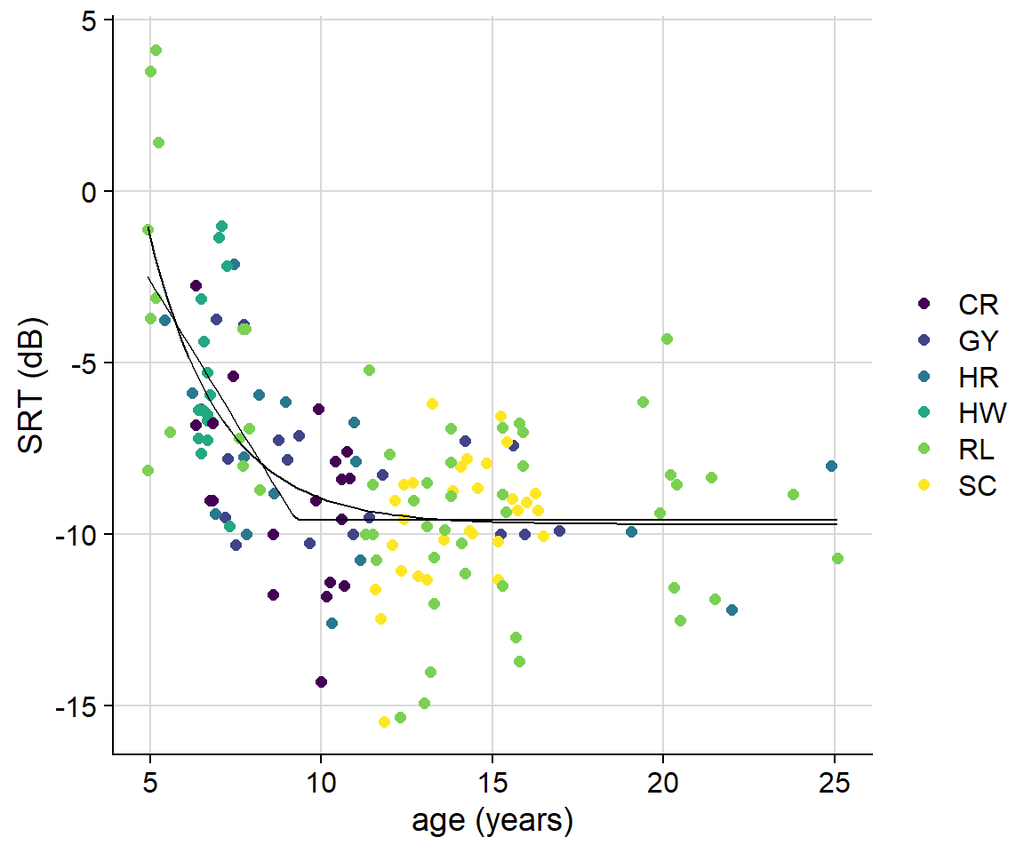

#### The standardised residuals look sufficiently unstructured. Note that the vertical line at left arises because the model predicts the same SRT for everyone over the age of 9.25 years.

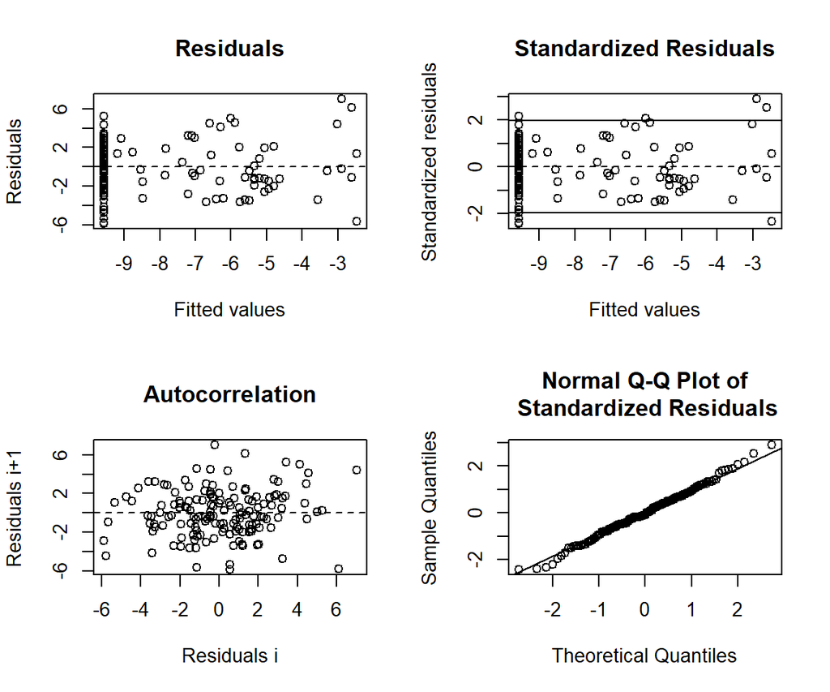

### Figure 4 from the paper

#### It could be that the variability in the younger children would be greater than that of the older, making suspect a simple calculation of a standardised residual. However, although the following graph shows a hint of that (in that the youngest children seem to be more dispersed), it essentially looks pretty good:

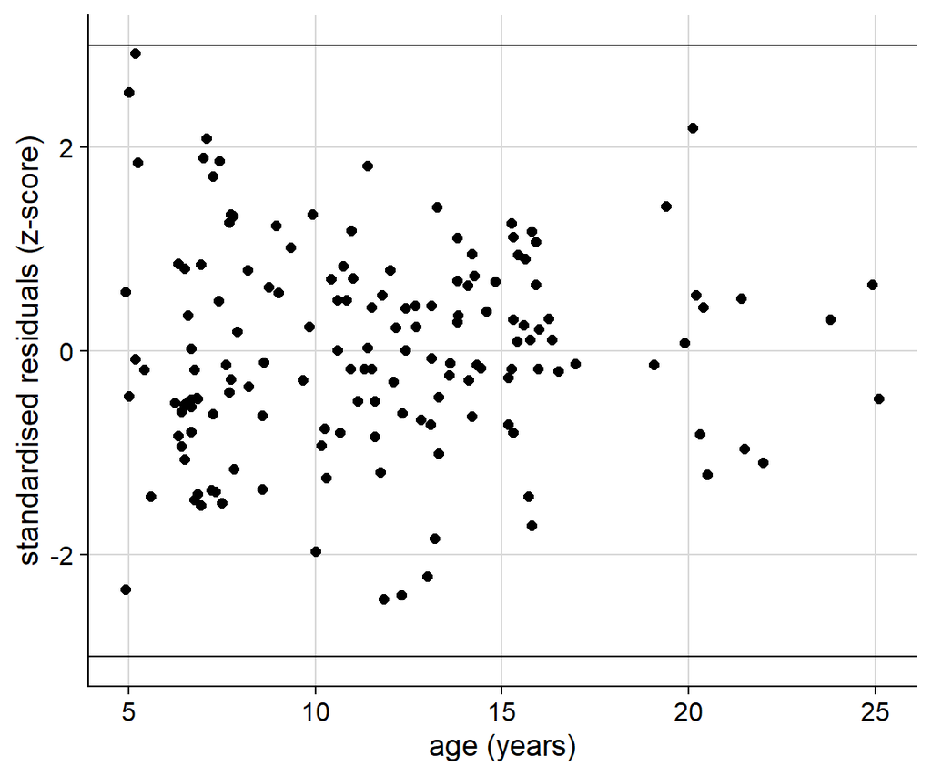

#### Although the tails of the empirical distribution may be a little heavy, there is no statistical evidence that the distribution of z scores is not Gaussian

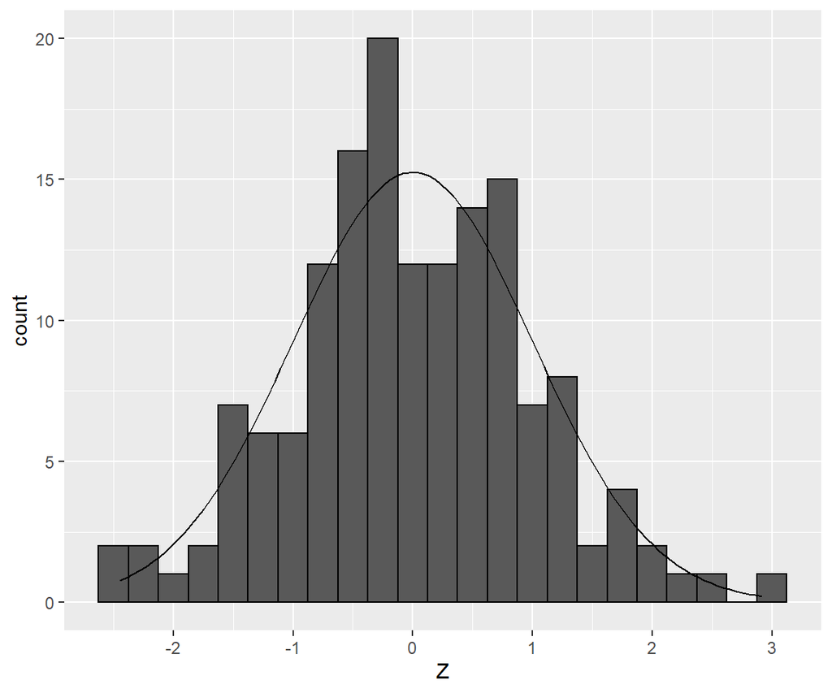

```
##
##  Shapiro-Wilk normality test
##
## data:  d$Z
## W = 0.99531, p-value = 0.9095
```

```
##
##  One-sample Kolmogorov-Smirnov test
##
## data:  d$Z
## D = 0.040581, p-value = 0.9627
## alternative hypothesis: two-sided
```